# Part 1: Brainstorming Ideas

### 1. Amusement Park

This idea would be studying an amusement park, specifically Hershey Park. This is an existing business and there is plenty of data that we can collect from studying its statistics. Our idea would be to analyze ticket sales and times of the day and year that customers are visiting the park. We have the end goal of finding the ideal time for people to attend the park where there would be shorter lines and less people there. The typical business day for an amusement park includes people either buying tickets online or at the ticket booth, then entering the park for the day. The amount of people that ride each ride each ride varies and depends on the season and marketability of each ride. The guests in the park can be sorted by age and gender. There are also gift-shops and food stands throughout the park that can bring insight into the amount of people in what area. The ideal “end-user” would be a potential customer that is looking to maximise time at the park. Our goal is to use the tables concerning ticket sales and season to figure out the peak time that the park is in operation.

**Tables**

- **Ticket Sales:** The number of people that purchase tickets. Whether it is an adult ticket or a child ticket. Whether they purchase season tickets, day ticket, hourly ticket. It will also look at the number of tickets sold. Need to see if the ticket was purchased online or in person at the park. A constraint to this would be if there was an adult purchasing tickets for smaller children.
- **People:** What people buy the tickets. This includes age range. We can look into how many children are with each adult.
- **Rides:** Will identify the popularity of different rides. Which age range rides the most.
- **Season:** What time of year the rides are open and when they are most popular.
- **In-park purchases:** the foos, gift-shop and merchandise purchases made when visitors are in the park, Can include the ages purchasing.

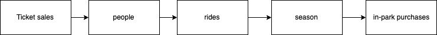

### 2. PSU FootBall Games

PSU football games are a popular attraction around campus that bring lots of revenue. It is an established business that has been operating for years. Our idea is to be able to analyze the stadium population throughout a game day. A typical game day starts with the number of people who have purchased tickets. Each year a certain number of tickets are sold to students and to the public. The number of tickets sold does not always represent the number of people that attend the games. The stadium is sectioned to students and the general public, who come in the game at different entrances and different times. Throughout the duration of the event, concession stands sell the same food and drink at different locations. The sales of the stands can be different based on where they are in the stadium. We will look into data collected by the business to gain insight into the most popular game times and people flow in the stadium. The “end-user” would be able to see how many people are in the stadium and where the bulk of the crowd is. This is in hopes that people will be able to find the most ideal time to attend and enter a PSU football game. Our goal is to analyze the peak times of fan arrival and departure while using data that looks at the activities and ticket sales during the game.

**Tables**

- **Ages:** The variety of ages that attend the game ranging from old alum, students and children. Who is the main audience at the games?
- **Ticket sales:** amount of tickets sold for each game, what is the average sales. Who is buying the tickets. A constraint to tickets sales is that we are not able to look at ticket resales
- **food sales:** amount of food sales for each game, the concession stands that are used the most. Most popular food item during the game. Times that food is bought.
- **game time:** time that the game starts. How many people buy for the 12pm, 3pm and 7pm games. Number of tickets sold each time range.
- **arrival time:** time people arrive before the game, what is the best time to arrive? How fast does the stadium fill in relation to the number of tickets sold and game time.

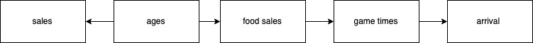

### 3. Cata Bus

It's a very relatable mode of transportation that almost everyone has used at least once, it's already an established business. A typical business day would be running two loops and two links, Blue Loop, White Loop, Red Link, Green Link. each running at different hours. Stopping on different routes, picking up and dropping off students on Penn State campus. There are peak times throughout the day where the bus is crowded and other times the bus is empty. The real-time end user data could look into the most popular time of the day that they bus is running. The relationships would carry out analyzing the amounts of students on the busses in different conditions. This will eventually lead to end user data where a person can see on which day, with what weather condition, at what time, and at which stop, the bus will have the most people or the least people on board so they can prepare accordingly. The goal of this data collection would be to analyze the usage of the CATAbus system by looking into the times that students are most likely to ride the busses and the paths that they take.

**Tables**

- **Bus route:** the route/type will examine the different loops and the number of stops that they make throughout its loop around campus.
- **People:** The ages of people who ride the busses. Can sort into year standing in college. Gender of those riding the bus.
- **Seasonal conditions:** the time of year that people are riding the bus. Gender, age and year standing of those riding the bus at these certain times.
- **time:** Time of the day that people are riding the bus. More in the morning or afternoon? can relate this table to time of year that people are riding the bus.
- **location:** Where the bus loads off the most students, where most students get on the bus. Can also analyze the busiest bus stop locations.

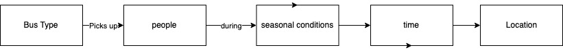